# act_report

### Analyzing and Visualizing Data

- We collected data from WeRateDogs Twitter archive for year 2015,2016 and 2017 and different sources for analyses.
- We wrangled the dataset and created visualization to answer some key questions.

### Question 1. Does high rating affects the dog popularity ? ( Assuming favorite_count is a criteria to decide dog's popularity)

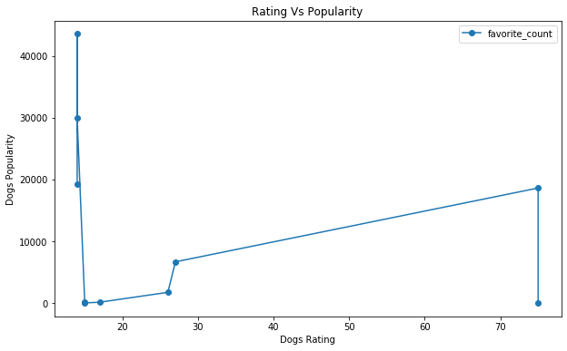

Our analyses result shows that there is no relation between Dog's rating and popularity. A highly rated dog doesn't mean that dog is more popular.

### Question 2. Most popular dog stage in terms of favorite_count and retweet_count

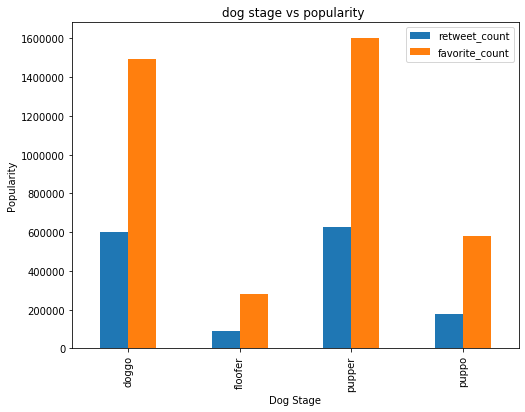

As per **Dogtionary** -

> `pupper (small dog) --> puppo (teenager dog) --> doggo (old dog)`  
> `floofer --> Any dog`

From above result we can say that `pupper` stage is the stage when dog is most popular. In other phrase, small dog is more popular than `teenager/puppo` and `old/doggo` dog.

`old/doggo dog` is more populatr than `teenager/puppo` but less popular than `small/pupper` dog

### Question 3. Which dogs breeds are most common.

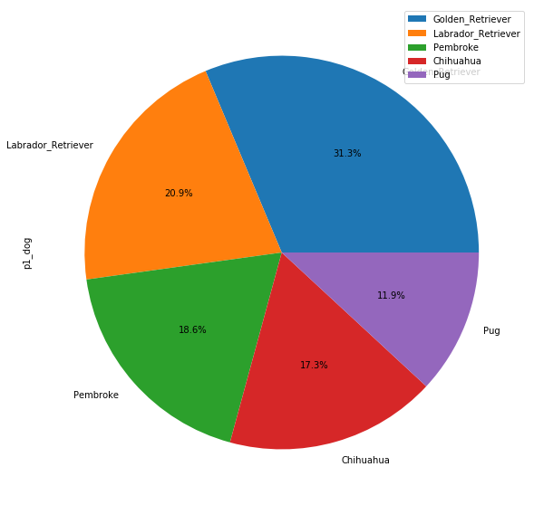

As per algorithm p1, `Golden_Retriever` is the most common dog breed and after that `Labrador_Retriever`.

### Question 4. In which month people are more active on Twitter

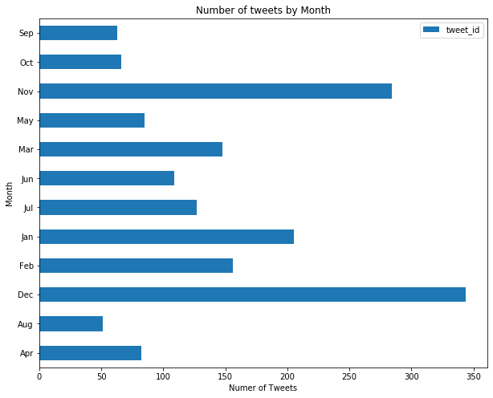

From above result we can say that, people are more active on Twitter in December month.

### Question 5. What are the different sources of tweets.

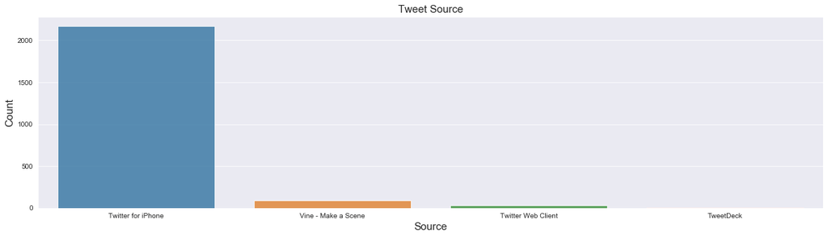

Above result shows that 'Twitter for iPhone' is the most popular platoform.